# Greenhouse Gas Emissions: Comparing the World’s Highest and Lowest Contributors

SDS 164A Fall 2024

Grace Nichols, Shen Rothermel

## Introduction

Our question is as follows: among six countries included in our data set, three with some of the lowest emissions recorded and three with some of the highest emissions, how do their respective greenhouse gas emissions compare and contrast? The following analysis will help us to unpack the intricacies of a critical global issue: climate change. Humans are a driving force of the climate crisis[^1] and, in order to craft an effective array of possible solutions, we need first to assess where emissions are stemming from. Knowing the sources of emissions, such as by industry sector and geographic location, provides us with necessary information we can use when attempting to mitigate the worst impacts of climate change. This analysis is essential because it is not fair to treat all countries and industries the same, given their noticeable differences in polluting levels. To construct equitable climate policies across the globe, one must know where the majority and the minority of greenhouse gasses are being emitted.

## Data

Our data comes from the Statistics Division of the Department of Economic and Social Affairs, in the United Nations. Various countries have independently, with assistance from the UN, gathered national data on CO2 and greenhouse gas emissions and reported this to the UN, which compiles it all into publicly available databases. This data has been reported and compiled annually from 2000 to 2021, including 1990, though many countries have not been consistent. Thus, there is some missing annual data, and some countries’ GHG emission levels data have not been recently updated. We will be looking at tonnes of CO2 produced (thousands or millions, depending on the data set) as well as millions of tonnes of GHG produced in total. For CO2, we will be utilizing available annual data to look at trends in levels of CO2 emissions over the past three decades. For GHG, we only have data from the most recent annual data for each country, which will be used primarily for comparing emission levels between countries. Throughout our graphs, we choose to focus on the following countries: Monaco, Malta, Iceland, Japan, the Russian Federation, and the United States of America. The first three have relatively low emission levels across the board, while the last three stand opposite with very high emission levels.

### Carbon Dioxide Emissions

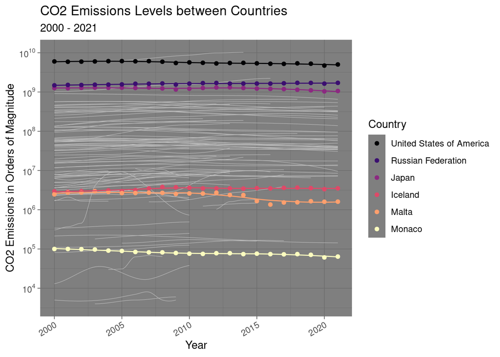

Figure 1. In terms of CO2 emissions levels, the United States of America leads ahead of the Russian Federation, followed closely by Japan. Monaco is the lowest out of the six countries in CO2 emissions levels, with Malta next and then Iceland. Gray lines represent all other countries included in the data set. The six highlighted countries are those with the lowest and highest CO2 emissions among countries with data for all years spanning from 2000 to 2021. CO2 emissions are measured in orders of magnitude or powers of 10. Data was recorded and compiled by the United Nations from countries around the world over the course of three decades. Year of data is reported, along with the country’s emissions levels measured in orders of magnitude of tonnes of CO2 for that year.

Although this graph cannot completely help us answer the question posed at the beginning, it provides insight into the stark differences in CO2 emissions among the six countries of interest. It seems that the United States emits the most carbon dioxide, Monaco emits the lowest amount of CO2, and the other countries lie in between the two. We have yet to see how emissions have changed from 2000 to 2021 for each individual country or each country’s total greenhouse gas emissions. However, the information provided by the graph strongly suggests that policy makers will need to focus more of their energy on implementing policies that reduce CO2 being emitted by the United States and other high polluting countries such as the Russian Federation.

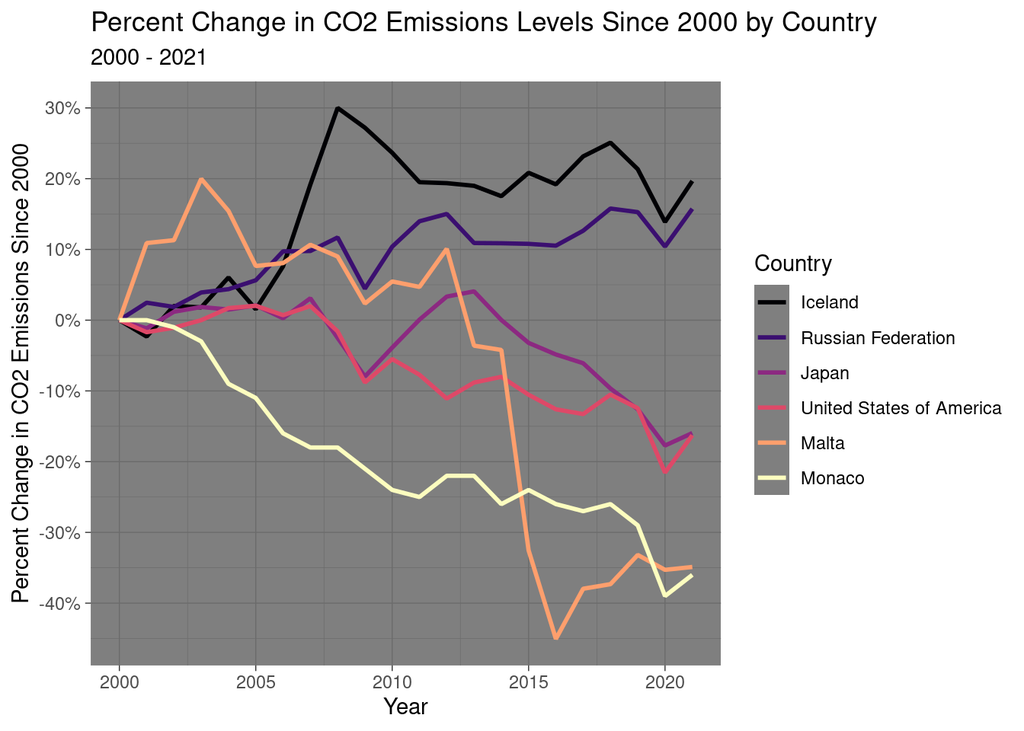

Figure 2. Monaco, Malta, Japan, and the United States of America trended down in CO2 emission levels (in millions of tonnes) between 2000 and 2021, while Iceland and the Russian Federation have had an increase during that time range. Data was recorded and compiled by the United Nations from countries around the world over three decades. Year of data is reported, along with the country’s emissions levels measured in millions of tonnes of CO2 for that year.

The graph above provides a partial answer for our question. Unsurprisingly, through the past 20 years, CO2 emissions have changed for all countries under investigation. From 2000 to 2021, Monaco’s CO2 emissions have steadily declined. The CO2 emissions of other countries such as Malta, the United States of America, and Japan have begun to invariably decline sometime after the year 2000. Unlike the other countries mentioned, the Russian Federation and Iceland have been increasing their carbon dioxide emissions since 2000. As large polluters, the direction in which the United States and Japan are moving regarding CO2 emissions would appear to be favorable. Even so, it is important to remember from the previous graph that Japan and the United States are still polluting in billions of tonnes while Malta and Iceland are polluting in millions of tonnes and Monaco is polluting in fractions of that. Thus, the United States and Japan will need to continue to reduce their emissions, possibly even more aggressively, in order to keep global degrees of warming at a desired amount [^2] [^3].

### Greenhouse Gas Emissions

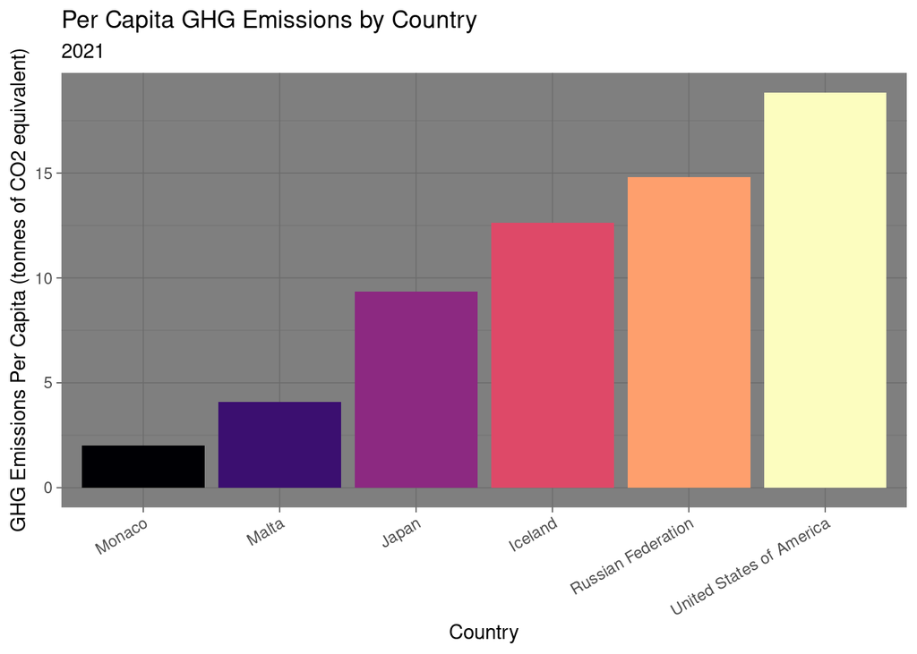

Figure 3. In 2021, the United States led ahead in per capita GHG emmisisons followed by the Russian Fderation, Iceland, Japan, Malta, and lastly Monaco. Data was compiled by the United Nations from countries around the world according to the latest year for recorded data available. The country’s per capita Greenhouse gas emissions are measured in tonnes of CO2 equivalent for that year.

This graph gives us insight into the question posed at the beginning by showing us what each country’s greenhouse gas emissions per capita were - how much, on average, the country produced for each person. Even at this level, the US holds a significant lead over the other countries at about 18 tonnes of CO2 equivalent per person.

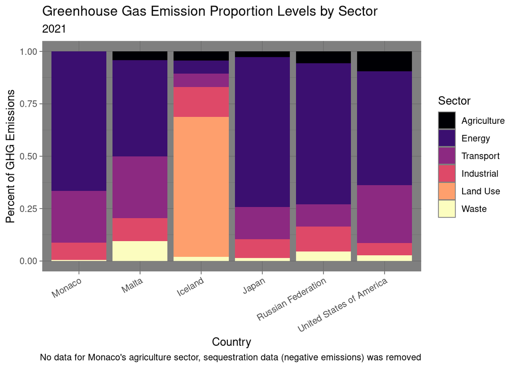

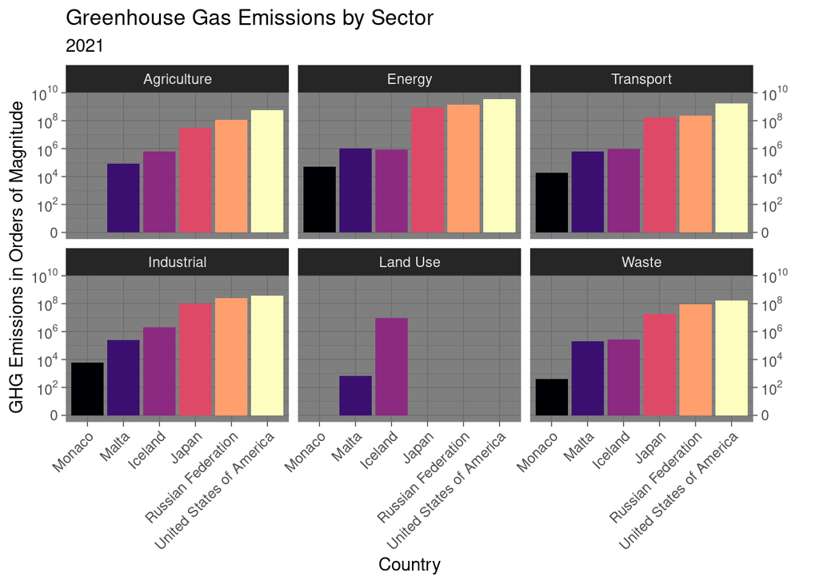

## Conclusion

It seems clear based on our explorations that the United States of America is the one of the highest greenhouse gas producers in the world, even going by sector or taking population into account. This suggests that when constructing equitable climate policies around the world, we may have to be stricter and harsher with the USA for the country to reach the same lower levels as some other countries. Additionally, we observe that countries like Iceland and the Russian Federation have had gradual increases in overall carbon dioxide emissions over the past couple decades - thus it may be imperative to identify the reasons for these increases, that are not observed in the other countries including the USA, and how to stop that unwanted growth. When tackling each country’s emissions individually, it seems a reasonable priority would be to understand what makes the energy sector such a large emitter, and invest more into pursuing solutions for reducing energy emissions. The exception in the countries of our focus is Iceland, which instead has land use dominating. This is a sharp contrast from most of the other countries which had negative land use emissions - understanding the reasoning for this and figuring out what we could do about it may also be beneficial. Overall, these data visualizations help us to get an idea of where potential problems may lie and inform us in the best way forward with constructing climate policies.

## Works Cited

[^1]: “The Causes of Climate Change.” NASA Science, NASA, 23 Oct. 2024, https://science.nasa.gov/climate-change/causes/.
[^2]: Fendt, Lindsay. “Why Did the IPCC Choose 2° C as the Goal for Limiting Global Warming?” MIT Climate Portal, 22 June 2021, https://climate.mit.edu/ask-mit/why-did-ipcc-choose-2deg-c-goal-limiting-global-warming.
[^3]: “A Degree of Concern: Why Global Temperatures Matter.” NASA Science, NASA, 19 June 2019, https://science.nasa.gov/earth/climate-change/vital-signs/a-degree-of-concern-why-global-temperatures-matter/.
[^4]: tdus. “Biological Carbon Sequestration.” UC Davis, 21 Aug. 2021, https://www.ucdavis.edu/climate/definitions/carbon-sequestration/biological.
[^5]: US EPA, OAR. “Sources of Greenhouse Gas Emissions.” 29 Dec. 2015, https://www.epa.gov/ghgemissions/sources-greenhouse-gas-emissions.
[^6]: “Land Use, Land-Use Change and Forestry (LULUCF).” United Nations Framework Convention on Climate Change, United Nations, https://unfccc.int/topics/land-use/workstreams/land-use--land-use-change-and-forestry-lulucf. Accessed 10 Dec. 2024.
[^7]: island.is. “Land and forest iceland. Land use emissions rise, but binding in forests rises.” 5 Jun. 2024, https://island.is/en/o/land-and-forest-iceland/news/losun-vegna-landnotkunar-eykst-en-binding-eykst-i-skogum.